# Struktury dat v R

Zpracovávání výzkumných dat pomocí jazyka R

## Program

- opakování z minulé hodiny
- kontrola domácího úkolu
- funkce v R
- datové struktury v R
- balíčky

## Kontrola domácí práce

1. vytvoření RProjektu
2. nový R skript
3. nahrání uložených dat

   ```r
   load("promenne.RData")
   ```

   Jde nahrát RData soubor i jiným způsobem? Jaké jsou nevýhody tohoto přístupu?
4. výpočet toho, kolik zaměstnanců s daným platem jde nabrat na specifikovanou dobu měsíců

   ```r
   (rozpocet%/%plat)/pocetMesicu
   ```

   ```
   [1] 3
   ```

5. A nešlo by to i jinak?

## Funkce v R

Nedílnou součástí kódu v R jsou takzvané funkce. Jedná se o **příkazy, které provedou specifickou akci za vámi definovaných podmínek**.

`název funkce(název argumentu = parametry argumentu)`

Pomocí funkce `seq` vygeneruj sekvenci s rozestupem po 3 od 10 do 20.

```r
seq(from = 10, to = 20, by = 3)
```

```
[1] 10 13 16 19
```

### Lze psát příkazy i bez definování argumentů?

```r
rep("ID", 5)
```

```
[1] "ID" "ID" "ID" "ID" "ID"
```

Ano; bez definování názvu argumentu se pracuje s jeho pořadím.

Je pořadí argumentů důležité? Ovlivní výsledek?

**Pozor!**

Na pořadí argumentu nezáleží, dokud jasně **definujeme k jakému argumentu parametr patří**.

### *Na doma*

### Rozdíl mezi `=` a `<-`

Možná jste se setkali s tím, že někdo zapisuje proměnné pomocí operátoru =. Funguje to?

```r
x = 6
x + 1
```

```
[1] 7
```

Proč se proto místo toho používá `<-` ?

```r
#definuj prvni argument a rovnou ho uloz jako promennou
rep(osobaID <- 5, 3)
```

```
[1] 5 5 5
```

```r
osobaID + 4
```

```
[1] 9
```

**R umožňuje provádět akce uvnitř “jiných akcí”**

V tomto případě určujeme argument na první pozici, a zároveň jeho hodnotu ukládáme do proměnné `osobaID`.

Na jaké problémy zde narazíme?

- `osobaID_2` není argument funce `rep`
  - operátor `=` ve funkci neznamená přiřazení, ale určení argumentu
    - samotný argument `osobaID_2` ve funkci `rep` neexistuje a proto nevznikne platný výsledek
- nedošlo k zapsání do globálního prostředí a tuto neexistující proměnnou proto nelze používat

### Samostatné cvičení

1. Můžeme zapsat sekvenci od 1 do 10 s počtem hodnot 3 pomocí následujícího kódu? Pokud ne, opravte.
2. Bez spuštění kódu určete, jaký bude výsledek této funkce. Používejte nápovědu, zkuste si jednotlivé části rozepsat.

   ```r
   length(rep(seq(2, 10, 2), 3))
   ```

#### Řešení úlohy 1)

Můžeme zapsat sekvenci od 1 do 10 s počtem hodnot 3 pomocí následujícího kódu? Pokud ne, opravte.

Ne, jelikož argument na třetí pozici v této funkci není `length.out`, který určuje délku sekvence, ale `by`, který určuje periodu.

**Čtěte dokumentaci pozorně!**

R dokumentace je psana mnoha lidmi a nemusí být vždy konzistentní.

Správná podoba kódu by tedy byla

```r
seq(from = 1, to = 10, length.out = 3)
```

```
[1]  1.0  5.5 10.0
```

#### Řešení úlohy 2)

Bez spuštění následujícího kódu určete, jaký bude výsledek této funkce. Používejte nápovědu, zkuste si jednotlivé části rozepsat.

Funkce `length` zjišťuje, jaká je “délka” objektu, jaký má počet hodnot. Potřebujeme proto spočítat, kolik hodnot nám vznikne jako výsledek funkce `rep`.

Funkce `rep` nám zde třikrát zopakuje výsledek daný funkcí `seq`.

Funkce `seq(2, 10, 2)` by zde mohla být zapsána na základě pořádí argumentů i jako `seq(from = 2, to = 10, by = 2)`. Výsledkem je tak sekvence `2 4 6 8 10`, která má pět čísel.

Třikrát se tedy zopakuje sekvence pěti čísel, což znamená že **výsledek je patnáct**.

## Vnořování funkcí

Jak bylo vidět v přechozích částech, R umožňuje používat funkce uvnitř dalších funkcí.

Pro R je hlavně důležité, aby **hodnoty v jednotlivých argumentech splňovaly jejich podmínky, nikoliv v jaké podobě tyto hodnoty do funkce vstupují**.

```r
trojka <- 3
rep(x = seq(1, 10, 3), times = trojka)
```

```
 [1]  1  4  7 10  1  4  7 10  1  4  7 10
```

V určité chvíli je ovšem dobré **přemýšlet i o čitelnosti samotného kódu**.

Který z následujících kódů je čitelnější?

```r
sample(x = rep(x = seq(1, 10, 3), times = 2), size = 4, replace = FALSE)
```

```
[1]  7 10  4 10
```

nebo

```r
opakovani <- rep(x = seq(1, 10, 3), times = 2)

sample(x = opakovani, size = 4, replace = FALSE)
```

```
[1]  7  7  4 10
```

## Datové struktury v R

### Vektor

> **série za sebou jdoucích hodnot totožného datového typu**
- vektor o jedné hodnotě je někdy nazýván *skalár*
- jednodimenzionální (důležité hlavně při vyhledávání)
- při použití více datových typů dochází k nucené konverzi do jednotného typu

```r
seq(1, 10, 2)
```

```
[1] 1 3 5 7 9
```

#### Jakými jinými způsoby můžeme vektory vytvořit?

- symbol `:` vytvoří sérii čísel v daných mezích
  - rozestup vždy po jedné

```r
-5:3
```

```
[1] -5 -4 -3 -2 -1  0  1  2  3
```

```r
0.65:9.18
```

```
[1] 0.65 1.65 2.65 3.65 4.65 5.65 6.65 7.65 8.65
```

- funkce `c` spojí hodnoty jakéhokoliv typu do vektoru

```r
c("jmeno", "prijmeni")
```

```
[1] "jmeno"    "prijmeni"
```

```r
c(1, 5, 77)
```

```
[1]  1  5 77
```

- **způsobů je mnohem více**, tyto se ale hodí znát

### Potenciální zádrhely

Datový typ vektoru bude **automaticky převeden na charakterový**, jelikož vektor v sobě **kombinuje několik datatypů** dohromady.

Jaký bude datový typ následujícího vektoru?

```r
vektorNA <- c(NA, 6, 9); vektorNA
```

```
[1] NA  6  9
```

NA označuje chybějící hodnotu, nikterak neurčuje samotný datový typ hodnoty.

**Tip**

Ke zjištění datového typu je možné použít funkci `mode`.

```r
mode(vektorNA)
```

```
[1] "numeric"
```

### Pojmenovávání hodnot

Jednotlivé hodnoty ve vektoru (ale i zbylých datových strukturách) je možné si pojmenovat.

```r
jmena <- c(jan = 22, dan = 667, sam = 6)
names(jmena) #jake pojmenovani ma danna promenna?
```

```
[1] "jan" "dan" "sam"
```

**Co znamená pojmenováná?**

Při pojmenovávání připojujeme specifické hodnotě či sérii hodnot určitý štítek. Nejenomže popisuje vlastnost hodnot(y), kterou pojmenovává, ale zárověň ho lze použít i k vyhledávání (indexování) jednotlivých hodnot. Více o indexování si řekneme v následující hodině.

**Pojmenování není to samé co přiřazování**; nevytváříme nové objekty, pouze hodnotám přidáváme novou charakteristiku.

#### Co když si chci zpětně vektor pojmenovat?

```r
vektorBezJmen <- c("Škoda", "Hyundai", "Vespa"); vektorBezJmen
```

```
[1] "Škoda"   "Hyundai" "Vespa"
```

```r
names(vektorBezJmen) #ma vektorBezJmen jmena?
```

```r
names(vektorBezJmen) <- c("Česko", "Japonsko", "Itálie"); vektorBezJmen
```

```
    Česko  Japonsko    Itálie
  "Škoda" "Hyundai"   "Vespa"
```

```r
names(vektorBezJmen)
```

```
[1] "Česko"    "Japonsko" "Itálie"
```

**Přiřazováním můžete měnit existující hodnoty**

**Přiřazování neslouží pouze k vytváření proměnných, může na nich provádět i změny**. Nemusí se jednat pouze o celé proměnné (které jsou pouze pojmenováním určité hodnoty či jejich skupiny) ale i specifické hodnoty uvnitř nich či hodnoty je popisující.

### Samostatné cvičení

1. Vypište alespoň tři rozdílné způsoby, jak získat následující vektor:
2. Vytvořte kód který upraví následující vektor tak, aby jména jednotlivých hodnot byla napsaná malými písmeny. Existuje pro toto i specifická funkce?

   ```r
   id <- c(JMENO = "jan", PRIJMENI = "novak")
   ```

3. Opravte následující kód tak, aby dával požadovaný výsledek; vektor s dvěmi hodnotami octavia se štítkem škoda.

#### Řešení úlohy 1)

Vypište alespoň tři rozdílné způsoby, jak získat následující vektor: 1 2 3 1 2 3 9 8 7 2

#### Řešení úlohy 2)

Vytvořte kód který upraví následující vektor tak, aby jména jednotlivých hodnot byla napsaná malými písmeny. Existuje pro toto i specifická funkce?

```r
names(id) <- c("jmeno", "prijmeni")
id
```

```
   jmeno prijmeni
   "jan"  "novak"
```

Existuje funkce v base R `tolower()`. Co způsobí a jakým způsobem ji můžeme použít?

```r
names(id) <- tolower(names(id))
id
```

```
   jmeno prijmeni
   "jan"  "novak"
```

**Pokud nevíte, hledejte** - spousta problémů a specifických use cases již byla dávno vyřešena a jsou k nalezení na internetu.

[figure not shown]

#### Řešení úlohy 3)

Opravte následující kód tak, aby dával požadovaný výsledek.

```r
rep(škoda = "octavia", 2)
```

```
[1] 2
```

Nesmíte zapomenout, že symbol = uvnitř funkcí značí argument. Má funkce `rep` argument škoda?

Nic ovšem nebrání tomu opakovat vektor s již jednou pojmenovanou hodnotou:

```r
rep(c(škoda = "octavia"), 2)
```

```
    škoda     škoda
"octavia" "octavia"
```

### Faktor

> **způsob uchovávání kategoriálních dat**
- používají se hlavně během analýz a vizualizací, lze je ale využít i při kontrole správnosti dat
- ukázka:

```r
ukazkaFaktory <- as.factor(c("west", "north", "west", "south", "east", "north",
                             "south", "east", "north")); ukazkaFaktory
```

```
[1] west  north west  south east  north south east  north
Levels: east north south west
```

- přestože vypadají jako charakterová data, ve skutečně se jedná o integery

```r
str(ukazkaFaktory)
```

```
 Factor w/ 4 levels "east","north",..: 4 2 4 3 1 2 3 1 2
```

#### Jakým způsobem vzniká vektor?

```r
abc <- as.factor(c("a", "b", "a", "c")); abc
```

```
[1] a b a c
Levels: a b c
```

R vytvoří kategorii z každé varianty a následně je seřadí v přehledu od nejnižší po největší.

```r
str(abc)
```

```
 Factor w/ 3 levels "a","b","c": 1 2 1 3
```

Jednotlivé kategorie je taktéž možné zobrazit pomocí funkce `levels`.

```r
levels(abc)
```

```
[1] "a" "b" "c"
```

**Funkce as.x() dokáže měnit více data typů/struktur**

Funkce `as.x()` dokážou měnit defacto všechny data typy/struktury:

```r
as.character(1:4)
```

```
[1] "1" "2" "3" "4"
```

```r
as.numeric("3")
```

```
[1] 3
```

```r
as.logical("FALSE")
```

```
[1] FALSE
```

### Pole (array)

> **objekt složený z vektorů stejného datového typu a délky v několika dimenzích**<sup>1</sup>
- jakým způsobem si představit dimenze?
  - Jedna dimenze: řada hodnot
  - Dvě dimenze: hodnoty v sloupcích a řádcích
  - Tři dimenze: dvě tabulky se sloupci a řádky naskládané za sebe
- k vytvoření se používá primárně funkce `array`
[^1]: Pro objekty v R platí, že pokud objekt obsahuje pouze jeden typ hodnot, tak je taktéž nazýván jako atomický vektor

### Vektor

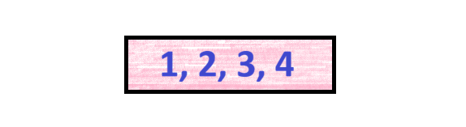

### Pole o dvou dimenzích (matice)

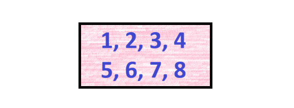

### Pole o třech dimenzích

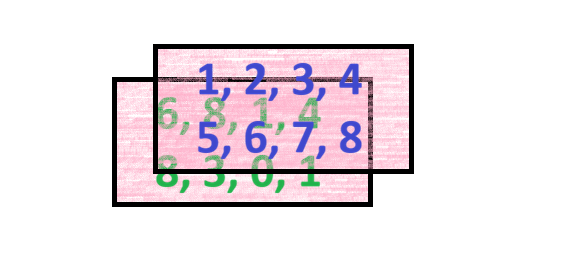

- use case
- nejvíce nás ale bude zajímat **datové pole o dvou dimenzích - matice**

### Matice (matrix)

> **dvojrozměrné pole**
- dvojrozměrný objekt znamená, že už se nejedná o objekt co má pouze jednu linii hodnot jako vektor, ale že **má řádky a sloupce**
  - defacto vektor ale poskládaný do řádků a sloupců místo toho aby byl natáhnutý
    - číslo v hranatých závorkách značí pozici hodnoty v dané dimenzi, více si k tomu ale řekneme v sekci indexování [Matice]
- při pokusu o vytvoření matice z více datových typů dojde stejně jako u vektoru k nucené konverzi na charakter

#### Tvorba matice

Matici lze vytvořit pomocí mnoha funkcí. Pokud ji chceme vytvořit celou od začátku, můžeme použít funkcí `matrix()`.

- `data`: hodnoty, které budou matici tvořit
- `nrow`: počet řádků
- `ncol`: počet sloupců
- …a další

**Automatické generování hodnot**

Při menším množství hodnot než je potřeba funkce `matrix` začne hodnoty opakovat. Pokud je více hodnot v `data` než je potřeba, dojde k erroru.

##### Co když ale chceme vytvořit matici z již existujících vektorů stejného typu a délky?

`cbind()` = spoj vektory po sloupcích (columns)

```r
cbind(1:3, 5:7)
```

```
     [,1] [,2]
[1,]    1    5
[2,]    2    6
[3,]    3    7
```

`rbind()` = spoj vektory po řádcích (rows)

```r
rbind(1:3, 5:7)
```

```
     [,1] [,2] [,3]
[1,]    1    2    3
[2,]    5    6    7
```

- Funkce `matrix()` taktéž umožňuje tvorbu matice po řádcích. Jak bychom toto provedli?
- Argument `byrow` je automaticky nastaven na hodnotu `FALSE`. Pro seřazení po řádcích (by row) je potřeba v matici zahrnout `byrow = TRUE`.

```r
matrix(1:6, nrow = 3, ncol = 2, byrow = TRUE)
```

```
     [,1] [,2]
[1,]    1    2
[2,]    3    4
[3,]    5    6
```

#### Procvičení

1. Vytvoř následující matici:
2. Vytvořte matici z následujících vektorů:

**Nezapomeňte na existenci NA!**

Matice potřebuje, aby všechny řádky (a sloupce) měly totožný počet hodnot. Funkce `rbind` a `cbind` tak **začne hodnoty v jednotlivých částech opakovat** tak dlouho, dokud jich nebude dostatečný počet na to, aby bylo možné fukci provést.

#### Pojmenování sloupců a řádků

Jak je vidět z předchozího cvičení, stejně jako u vektoru **můžeme pojmenovat každou z jednotlivých součástí**, totéž můžeme provést i u matic.

```r
matice <- matrix(1:6, 2, 3); matice
```

```
     [,1] [,2] [,3]
[1,]    1    3    5
[2,]    2    4    6
```

```r
rownames(matice) #jaka jsou jmena radku
```

```r
colnames(matice) #jaka jsou jmena sloupcu
```

Pokud chceme přiřadit jména ke sloupcům či řádkům, musíme tak provést přiřazením vektoru o totožné délce.

```r
rownames(matice) <- c("pocetMereni", "pocetProbandu")
colnames(matice) <- c("pokus1", "pokus2", "pokus3")
matice
```

```
              pokus1 pokus2 pokus3
pocetMereni        1      3      5
pocetProbandu      2      4      6
```

### Samostatné cvičení

1. Vytvořte matici, která bude mít 5 sloupců a 2 řádky a bude obsahovat prvních 10 lichých čísel. Následně připojte k matici další sloupec, tentokrát pouze s číslem 2.  
   Sloupce pojmenujte pomocí numerických a řádky pomocí charakterových hodnot.
2. Vytvořte následující matici:

   **HARD MODE: JEDEN ŘÁDEK KÓDU NA DRUHOU ÚLOHU A ŽÁDNÉ RBIND**

#### Řešení úlohy 1)

1. Vytvořte sekvenci lichých čísel (každé číslo objedno od 1 dále) v počtu deseti hodnot.

   ```r
   seq(by = 2, length.out = 10)
   ```

   ```
    [1]  1  3  5  7  9 11 13 15 17 19
   ```

   ```r
   #nebo taky samozrejme c(1, 3, 5, 7, 9, 11, 13, 15, 17, 19), ale....
   ```

2. Použij sekvenci jako hodnoty do matice, rozděl je do pěti sloupců a dvou řádků.

   ```r
   hotovaMatice <- matrix(seq(by = 2, length.out = 10), ncol = 5); hotovaMatice
   ```

   ```
        [,1] [,2] [,3] [,4] [,5]
   [1,]    1    5    9   13   17
   [2,]    3    7   11   15   19
   ```

3. Připoj k matici další sloupec tvořený vektorem s takovým počtem hodnot jako je počet řádků

   ```r
   hotovaMatice <- cbind(hotovaMatice, c(2, 2)); hotovaMatice
   ```

   ```
        [,1] [,2] [,3] [,4] [,5] [,6]
   [1,]    1    5    9   13   17    2
   [2,]    3    7   11   15   19    2
   ```

4. Pojmenuj sloupce a řádky

   ```r
   colnames(hotovaMatice) <- 1:ncol(hotovaMatice) #fce ncol da zpet pocet sloupcu, stejne jako nrow radku
   rownames(hotovaMatice) <- c("czech", "slovak")
   hotovaMatice
   ```

   ```
          1 2  3  4  5 6
   czech  1 5  9 13 17 2
   slovak 3 7 11 15 19 2
   ```

#### Řešení úlohy 2)

1. Jelikož potřebujeme poskládat numerické vektory 15:20 a 37:42 dohromady šestkrát pod sebou, musí být spojené po řádcích. Kromě `rbind` tuto možnost poskytuje i parametr `byrow = TRUE` ve funkci `matrix`.

   ```r
   #matrix(?, byrow =  TRUE)
   ```

2. Potřebujeme proto vyvořit sekvenci hodnot, které dáme R k dispozici pro vytvoření matice. To znamená, že musíme sestavit sekvenci šestkrát za sebou alternativně opakujících se vektorů 15:20 a 37:42.  
   Toho dosáhneme pomocí funkce `rep`.

   ```r
   rep(c(15:20, 37:42), 3)
   ```

   ```
    [1] 15 16 17 18 19 20 37 38 39 40 41 42 15 16 17 18 19 20 37 38 39 40 41 42 15
   [26] 16 17 18 19 20 37 38 39 40 41 42
   ```

3. Je potřeba, aby počet sloupců byl přesně takový, jako je počet hodnot ve vektorech, jinak by se nám nerozdělily do pravidelně se opakujících řádků.

   ```r
   matrix(rep(c(15:20, 37:42), 3), ncol = length(15:20), byrow = TRUE)
   ```

   ```
        [,1] [,2] [,3] [,4] [,5] [,6]
   [1,]   15   16   17   18   19   20
   [2,]   37   38   39   40   41   42
   [3,]   15   16   17   18   19   20
   [4,]   37   38   39   40   41   42
   [5,]   15   16   17   18   19   20
   [6,]   37   38   39   40   41   42
   ```

Možná vás napadlo, zda by nešlo určit popisky sloupců a řádků už přímo v zadání matice. Je to možné, a to pomocí atributu `dimnames`.

```r
matrix(1:6, ncol = 3,
       dimnames = list(c("cesko", "slovensko"), 10:12),
       byrow = TRUE)
```

```
          10 11 12
cesko      1  2  3
slovensko  4  5  6
```

Do parametru `dimnames` se vloží list, který bude obsahovat názvy pro každou dimenzi (zde řádky a sloupce). Co je to ale list?

### Seznam (list)

```r
list(name = c("William Hartnell","Patrick Troughton","Jon Pertwee","Tom Baker","Peter Davison","Colin Baker","Sylvester McCoy","Paul McGann", "John Hurt","Christopher Eccleston"),
               year = c(55,46,50,40,29,40,44,36,73,41),
               episodes = c("134","119","128","172","69","31","42","1","2","13"))
```

```
$name
 [1] "William Hartnell"      "Patrick Troughton"     "Jon Pertwee"
 [4] "Tom Baker"             "Peter Davison"         "Colin Baker"
 [7] "Sylvester McCoy"       "Paul McGann"           "John Hurt"
[10] "Christopher Eccleston"

$year
 [1] 55 46 50 40 29 40 44 36 73 41

$episodes
 [1] "134" "119" "128" "172" "69"  "31"  "42"  "1"   "2"   "13"
```

[^2]: někdy můžete narazit na pojem rekurzivní vektor: aneb objekt, který může mít více data typů a obsahovat další objekty

#### Procvičení

1. Vytvořte objekt, který v sobě bude obsahovat informace o probíhajícím výzkumu. Bude obsahovat jeho název, jména a identifikační číslo dvou výzkumníků a soupis toho, zda se jim podařilo v pěti experimentech octomilky úspěšně rozmnožit.

### Data frame

#### Tvorba data frame

Nejjednoduší působ, jak vytvořit data frame je skrz stejnojmou funkci `data.frame`.

```r
data.frame(obec = c("Čeladná", "Jáchymov", "Chýně"),
           PSČ = c(73912, 36251, 25303),
           okres = c("Frýdek-Mýstek", "Karlovy Vary", "Praha-západ"),
           row.names = c("id_01", "id_02", "id_03"))
```

```
          obec   PSČ         okres
id_01  Čeladná 73912 Frýdek-Mýstek
id_02 Jáchymov 36251  Karlovy Vary
id_03    Chýně 25303   Praha-západ
```

Co se stane, pokud se snažíme do data frame vložit **objekt, který je jiné délky než zbylé**?

**Nezapomeňte na existenci NA!**

```r
data.frame(obec = c("Čeladná", "Jáchymov", "Chýně"),
           PSČ = c(73912, 36251, NA),
           okres = c("Frýdek-Mýstek", "Karlovy Vary", "Praha-západ"),
           row.names = c("id_01", "id_02", "id_03"))
```

```
          obec   PSČ         okres
id_01  Čeladná 73912 Frýdek-Mýstek
id_02 Jáchymov 36251  Karlovy Vary
id_03    Chýně    NA   Praha-západ
```

#### Pojmenovávání sloupců a řádků

- **řádky:**
  - pomocí argumentu `row.names,`vždy potřeba definovat název pro každý řádek!

    ```r
    data.frame(obec = c("Čeladná", "Jáchymov", "Chýně"),
               PSČ = c(73912, 36251, 25303),
               okres = c("Frýdek-Mýstek", "Karlovy Vary", "Praha-západ"),
               row.names = c("id_01", "id_02", "id_03"))
    ```

    ```
              obec   PSČ         okres
    id_01  Čeladná 73912 Frýdek-Mýstek
    id_02 Jáchymov 36251  Karlovy Vary
    id_03    Chýně 25303   Praha-západ
    ```

  - pozdější doplnění pomocí funkce `rownames`

    ```r
    lokace <- data.frame(obec = c("Čeladná", "Jáchymov", "Chýně"),
               PSČ = c(73912, 36251, 25303),
               okres = c("Frýdek-Mýstek", "Karlovy Vary", "Praha-západ"))
    rownames(lokace) <- c("id_01", "id_02", "id_03")
    ```

- **sloupce:**
  - pojmenování jednotlivých datových struktur, ze kterých se má data frame skládat, pomocí štítku (název = hodnota)

    ```r
    data.frame(obec = c("Čeladná", "Jáchymov", "Chýně"),
               PSČ = c(73912, 36251, 25303),
               okres = c("Frýdek-Mýstek", "Karlovy Vary", "Praha-západ"))
    ```

    ```
          obec   PSČ         okres
    1  Čeladná 73912 Frýdek-Mýstek
    2 Jáchymov 36251  Karlovy Vary
    3    Chýně 25303   Praha-západ
    ```

  - použití již dříve vytvořených objektů

    ```r
    obec <- c("Čeladná", "Jáchymov", "Chýně")
    PSČ <- c(73912, 36251, 25303)
    okres <- c("Frýdek-Mýstek", "Karlovy Vary", "Praha-západ")

    data.frame(obec, PSČ, okres)
    ```

    ```
          obec   PSČ         okres
    1  Čeladná 73912 Frýdek-Mýstek
    2 Jáchymov 36251  Karlovy Vary
    3    Chýně 25303   Praha-západ
    ```

  - pozdější doplnění pomocí funkce `colnames`

    ```r
    lokace <- data.frame(c("Čeladná", "Jáchymov", "Chýně"),
               c(73912, 36251, 25303),
               c("Frýdek-Mýstek", "Karlovy Vary", "Praha-západ"))
    colnames(lokace) <- c("obec", "PSČ", "okres")
    lokace
    ```

    ```
          obec   PSČ         okres
    1  Čeladná 73912 Frýdek-Mýstek
    2 Jáchymov 36251  Karlovy Vary
    3    Chýně 25303   Praha-západ
    ```

- **oboje najednou:**
  - použitím funkce `dimnames` lze najednou nastavit názvy pro obě dimenze

    ```r
    dimnames(lokace) <- list(c("id_01", "id_02", "id_03"),
                             c("obec", "psc", "okres"))
    lokace
    ```

    ```
              obec   psc         okres
    id_01  Čeladná 73912 Frýdek-Mýstek
    id_02 Jáchymov 36251  Karlovy Vary
    id_03    Chýně 25303   Praha-západ
    ```

    - Proč zde používáme list? Pokud si nepamatujete, podívejte se do nápovědy :]

#### Jiné způsoby tvorby data frame

Nešlo by ale přeci k vytvoření data frame jednoduše použít `cbind` nebo `rbind`? Pojďme si to vyzkoušet.

```r
cbind(c("Čeladná", "Jáchymov", "Chýně"),
      c(73912, 36251, 25303),
      c("Frýdek-Mýstek", "Karlovy Vary", "Praha-západ"))
```

```
     [,1]       [,2]    [,3]
[1,] "Čeladná"  "73912" "Frýdek-Mýstek"
[2,] "Jáchymov" "36251" "Karlovy Vary"
[3,] "Chýně"    "25303" "Praha-západ"
```

**Jaký typ objektu je výsledek?** Jedná se o data frame?

**class vs mode**

Funkce `mode` nám zjistí, o jaký datový typ se jedná. Fuknce `class` nám nejenomže zjistí více informací, ale hlavně nám řekne, jak se vůči danému objektu R bude chovat.

Funkce `cbind` a `rbind` **vytvoří data frame pouze v případě, že alespoň jeden z objektů svazovaných dohromady je již data frame**, jinak vytvoří matici.

Pro vytvoření data frame pomocí spojení objektů jako sloupců či řádků je třeba využít přímo funkce `cbind.data.frame` a `rbind.data.frame`.

### Procvičení

1. Spojte následující vektory po sloupcích do data frame. Následně k němu doplňte jména řádků, které budou libovolný text.

### Samostatné cvičení

1. Vytvořte následující data frame:
2. Doplňte k data frame z první úlohy sloupec `clearSample`, který v sobě bude obsahovat náhodně vybrané hodnoty `TRUE` či `FALSE`. Výběr hodnot proveďte pomocí funkce.
3. Z následujících vektorů (bez jejich upravování) vytvořte data frame a pojmenujte první sloupec jako `znamky` a třetí jako `predmety`.

```r
sample(1:5, 6, replace = TRUE)
```

```
[1] 5 4 5 4 3 5
```

```r
jmenaZaku <- c("LK", "SD", "AE", "IR"); jmenaZaku
```

```
[1] "LK" "SD" "AE" "IR"
```

```r
rep(c("ČJ", "biologie", "španělština"), 2)
```

```
[1] "ČJ"          "biologie"    "španělština" "ČJ"          "biologie"
[6] "španělština"
```

#### Řešení úlohy 1)

1. Vypište jednotlivé sloupce jako vektory.

   ```r
   vek <- c(27,35,30,47,42)
   sex <- c("female","male","male","female","female")
   strana <- c("sin","sin","dx","dx","dx")
   ```

2. Volitelné; vytvořte si vektor pro jména řádků.

   ```r
   id <- c("SC_001", "SC_007", "SC_013", "SC_014", "SC_020")
   ```

3. Pomocí funkce `data.frame` spojte sloupce dohromady a popište řádky.

   ```r
   vzorek <- data.frame(vek, strana, sex, row.names = id); vzorek
   ```

   ```
          vek strana    sex
   SC_001  27    sin female
   SC_007  35    sin   male
   SC_013  30     dx   male
   SC_014  47     dx female
   SC_020  42     dx female
   ```

**Pojmenování výsledného data frame**

Data frame si nemusíte pojmenovávat, ale vzhledem k úloze 2) se to hodí.

#### Řešení úlohy 2)

1. K data frame potřebujeme připojit nový sloupec. Jeden ze způsobů jak to provést (další se naučíme později) je vytvoření nového pojmenovaného vektoru s jeho připojení ke stávajícímu data frame. Vytvořme si proto vektor, který bude obsahovat náhodný výběr boolean hodnot.

   ```r
   clearSample <- sample(c(TRUE, FALSE),
                  size = length(strana), replace = TRUE)
   #potrebujeme tolik hodnot jako je jich v teremkoliv jinem sloupci
   #proto pouzijeme length(nazev nami ulozeneho vektoru)
     #ano, jde to pocitat i rucne
       #ale co kdyz toho budete mit opravdu hodne?
   ```

2. Spojíme dohromady data frame z první úlohy a nový vektor. Pro snadnou práci doporučuji si data frame pojmenovat (viz předchozí úloha).

   ```r
   vzorek <- cbind.data.frame(vzorek, clearSample); vzorek
   ```

   ```
          vek strana    sex clearSample
   SC_001  27    sin female       FALSE
   SC_007  35    sin   male        TRUE
   SC_013  30     dx   male        TRUE
   SC_014  47     dx female        TRUE
   SC_020  42     dx female        TRUE
   ```

   ```r
   #rovnou si i výsledek znovu uložíme
   ```

**Opakované spuštění ukládání kódu s novými údaji**

Co se stane, pokud výše zmíněný kód projedeme několikrát? A proč?

Při opakovaném spuštění kódu, kde se přidávají/ubírají části objektu anásledně se výsledek ukládá pod totožným názvem, bude docházet k tomu, že se změny provedou vždy na výsledku předchozí iterace. **Opakovaným spouštěním kódu a jeho ukládáním v této úloze by tak docházelo k opakovanému přidávání sloupce `clearSample` ad nauseum.**

#### Řešení úlohy 3)

1. Jednoduchým způsobem, jak si vytvořit dataframe s přiřazováním názvů, je použít funkci `data.frame`. Vytvořme si proto data frame z dodaných vektorů a dle zadání je pojmenujme tak, aby nám z toho vznikly správné názvy sloupců.

**Proč nepojmenováváme vektor, který v sobě obsahuje jména žáků?**

Protože tím, že jsme si vektor přiřadili k určitému názvu, tak už v sobě obsahuje informace o jménu, které R použije jako název sloupce.

2. Kód nám hodí error, jelikož se pokoušíme do data frame, který musí mít vždy stejnou délku sloupců či řádků, vložit vektor, který je kratší jak ostatní. Potřebujeme si tedy zjistit, o který se jedná.

```r
length(sample(1:5, 6, replace = TRUE))
```

```
[1] 6
```

```r
length(jmenaZaku)
```

```
[1] 4
```

```r
length(rep(c("ČJ", "biologie", "španělština"), 2))
```

```
[1] 6
```

Vidíme, že vektor `jmenaZaku` je o dvě hodnoty kratší jak ostatní. **Abychom mohli data frame i tak stvořit, je potřeba, abychom upravili délku sloupce, který obsahuje vektor `jmenaZaku` na stejný počet hodnot jako ostatní.**

3. Pokud potřebujeme přidat chybějící hodnoty, jednoduše použijeme `NA`. Zadání nám ovšem neumožňuje upravovat vlastní vektor `jmenaZaku`. Jak jinak můžeme `NA` hodnoty v data frame doplnit?

Nic nám nezakazuje **použít vektor uvnitř dalšího vektoru**.

```r
data.frame(znamky = sample(1:5, 6, replace = TRUE),
           jmenaZaku = c(jmenaZaku, NA, NA),
           predmety = rep(c("ČJ", "biologie", "španělština"), 2))
```

```
  znamky jmenaZaku    predmety
1      3        LK          ČJ
2      5        SD    biologie
3      5        AE španělština
4      5        IR          ČJ
5      2      <NA>    biologie
6      5      <NA> španělština
```

### Tibble

> **data frame ale ✧･ﾟ: *✧･ﾟ:vylepšené:･ﾟ✧*:･ﾟ✧**
- stejná funkce jako data frame, ale v některých oblastech vylepšená
  - ukazuje například rovnou rozměry a data typy jednotlivých sloupců
  - snadněji zvládá objemnější datasety
- ukázka:

```r
  tibble::tibble(
    id = 1:4,
    jmeno = c("Ivo", "Oto", "Anna", "Bára"),
    vek = c(25, 29,30, 35),
    role = c("Engineer", "Data Scientist", "Developer", "HR"),
    plat = c(45000,60000, 80000, 100000)
  )
```

```
# A tibble: 4 × 5
     id jmeno   vek role             plat
  <int> <chr> <dbl> <chr>           <dbl>
1     1 Ivo      25 Engineer        45000
2     2 Oto      29 Data Scientist  60000
3     3 Anna     30 Developer       80000
4     4 Bára     35 HR             100000
```

- Funkce `tibble` není součástí základního R, ale je v balíčku `tibble`, který je následně součástí metabalíčku `tidyverse`.

## Balíčky v R

S balíčky jsme se krátce seznámili již v první lekci, zde si je ale probereme podrobněji.

#### Co je to balíček (package)?

- **nezávisle vytvořená sada funkcí, objektů a dat**, které slouží k vyřešení určitého problému a které je možné si stáhnout a používat
  - proč si ručně vytvářet celou novou funkci, která by nám třídila data dle námi daných kategoií, když to již někdo vytvořil jako funkci `group_by` v balíčku `dlyr`?

#### Jak ho získám?

1. funkce `install.packages("název balíčku")`
2. výběrem skrz rozhraní

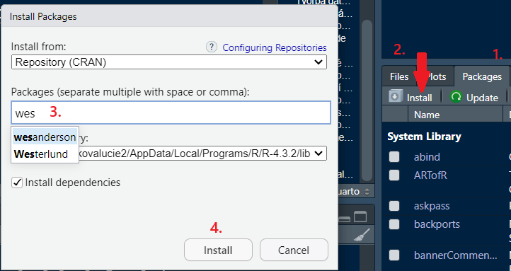

### Spuštění balíčku

Po instalaci/stažení se nám balíček uloží v počítači, **Před tím, než ho budeme používat, tak ho musíme do R nahrát**; říci mu, že v tuto chvíli má hledat spuštěné funkce nejenom v base R , ale i v dalších místech na našem počítači.

**Proč se balíčky nenahrávají automaticky?**

Každý nahraný a otevřený balíček zabírá místo - pokud bychom automaticky nahrávali veškeré stažené balíčky, **R by se nám velmi výrazně zpomalilo**.

**Jak si balíček nahrajeme do R?**

1. pomocí funkce `library(název balíčku)`<sup>1</sup>
2. výběrem skrze rozhraní

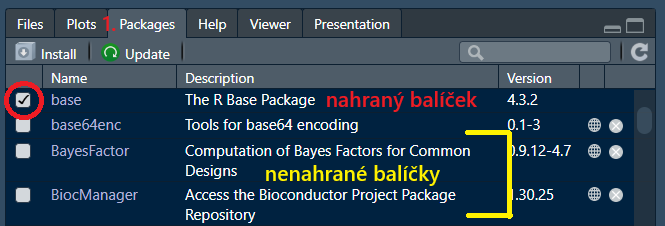

[^3]: Dokázal by mi někdo říct, proč při instalaci používáme uvozovky u názvu balíčku, ale ve funkci `library` ne? :]

### Konflikty v balíčcích

Je možné, že **dva či více balíčků budou obsahovat funkci s totožným názvem**. Jak potom R pozná, z kterého balíčku má danou funkci použít?

**Nejnověji nahraný balíček má prioritu**

Při nahrávání balíčků má **nejnověji nahraný balíček vždy prioritu nad dříve nahranými balíčky**. Pokud si ráno nahrajete balíček 1 s funkcí `x` a odpoledne balíček 2, taktéž s funkcí `x` a funkci začnete používat, bude použita funkce `x` z balíčku 2.

#### Co když si nechci nahrát celý balíček/chci použít verze funkce ze specifického balíčku?

**R umožňuje nahrávat funkce ze specifických balíčků tak, aby “nepřepsaly” již používané funkce**. A to pomocí symbolu `::`.

`název balíčku::funkce`

```r
tabulka <- tibble::tibble(
  id = 1:4,
  jmeno = c("Ivo", "Oto", "Anna", "Bára"),
  vek = c(25, 29,30, 35),
  role = c("Engineer", "Data Scientist", "Developer", "HR"),
  plat = c(45000,60000, 80000, 100000)
); tabulka
```

```
# A tibble: 4 × 5
     id jmeno   vek role             plat
  <int> <chr> <dbl> <chr>           <dbl>
1     1 Ivo      25 Engineer        45000
2     2 Oto      29 Data Scientist  60000
3     3 Anna     30 Developer       80000
4     4 Bára     35 HR             100000
```

Pomocí funkce `tibble` ze stejnojmenného balíčku jsme si vytvořili tibble tabulku.

## Příprava na další hodinu

Nainstalujte si balíček [`tidyverse`](https://tidyverse.org/packages/). Počítejte s tím, že balíček se bude stahovat a instalovat klidně i **několik desítek minut** - záleží na vašem počítači.

## Domácí úkol

1. Vytvořte vektor, který v sobě bude mít větu “Tea is better than coffee”. Pokuste se přijít na to, jakým způsobem byste mohli z tohoto vektoru vytvořit druhý vektor, co bude obsahovat hodnoty “Tea” “is” “better” “than” “coffee”. Nezapomeňte, StackOverflow a jiné stránky jsou vaši nejlepší kamarádi ;)
2. Vytvořte list, který bude obsahovat informace o vašem oblíbeném filmu; jeho název, kdo jej režiséroval, kdy byl vydán, alespoň tři jména herců a hereček, kteří v něm hráli, na jaké ceny byl nominován a jaké společnosti se angažovaly jako jeho producenti. Jakmile budete mít list vytvořený, připojte do seznamu herců/hereček Zaphoda Beeblebroxe. Pokuste se připojení provést pomocí (nové) funkce, ale pokud naleznete jiný a jednodušší způsob jak toto provést, který jsme si ještě neukazovali, zkuste použít ten :).
3. Kolik odlišných hodnot je v následujícím vektoru?

```r
c(3, 2, 7, 45, 2, 6, 11, 7,
  90, 76, 4, 3, 46, 45, 7,
  89, 6, 45, 1, 55, 12, 90,
  2, 67, 2, 8, 7, 4, 34, 6)
```

```
 [1]  3  2  7 45  2  6 11  7 90 76  4  3 46 45  7 89  6 45  1 55 12 90  2 67  2
[26]  8  7  4 34  6
```

Skript zašlete nejpozději do pátku před příští hodinou na lucie.hoskova@ruk.cuni.cz

## Tipy navíc pro samostudium

### Aktualizace R a RStudio

Je doporučené pravidelně aktualizovat jak R tak RStudio, abyste vždy pracovali s nejaktuálnějšími verzemi.

#### RStudio

RStudio vyžaduje manuální aktualizaci. Můžete odkiknout popup okno co na vás vyskočí při spuštění, a nebo novou verzi stáhnout skrz `Help < Check for Rstudio Updates`.

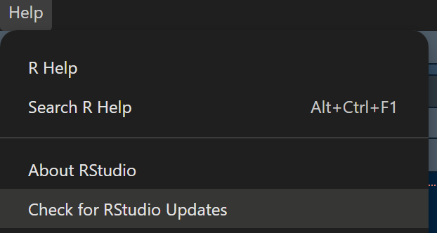

Existuje způsob, jak si tuto činnost alespoň částečně automatizovat.

#### R

**Windows**

Jak si případně můžete **zjistit, kterou verzi R používáte**?

Aktuálně používaná verze je vždy zobrazena v konzoli.

[figure not shown]

Jde si to samozřejmě ale zjistit i pomocí kódu.

```r
R.version.string
```

```
[1] "R version 4.6.1 (2026-06-24 ucrt)"
```

**Potřeba přeinstalování balíčků**

Po instalaci nové verze R je vždy potřeba přeinstalovat balíčky - **R se totiž instaluje bez nich**. Můžete to provést ručně přímo kopírováním z Program Files, doporučuji vám ale spíše používat funkce.

### Aktualizace balíčků

**Lze aktualizovat pouze nenahrané balíčky**

**Pokud máte některý z balíčků otevřený, nebude jej možné aktualizovat.**

A nebo odkliknutím v RStudio:

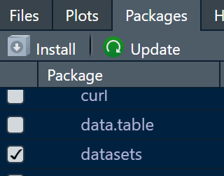

#### Ručně v prostředí RStudia

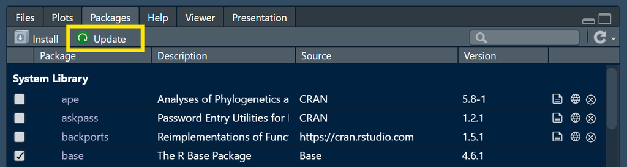

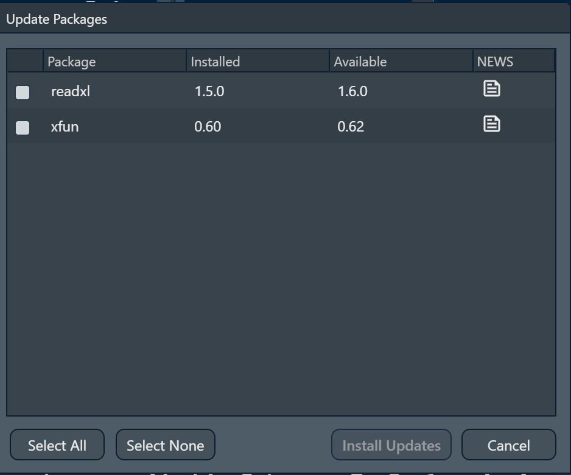

Tato verze umožňuje taktéž **aktualizaci pouze vybraných balíčků**.

Pokud chcete aktualizovat specifický balíček ručně, stačí ho znovu instalovat pomocí `install.packages`.

### Změna verze R, ve kterém se pracuje

Některé balíčky po vás budou vyžadovat práci ve starší verzi R, protože s novou nejsou kompatibilní.

**Je možné si nastavit, se kterou verzí R právě pracujete**.

#### V RStudio

`Tools < Global Options... < General < R version`

[figure not shown]

Je důležité vědět, že **funkce `updateR` automaticky maže starší verze R pokud neurčíte jinak**, takže si je budete muset stáhnout znovu.